# Oil x Envr Analysis Scratch

KCF

2/12/2021

## Scratch for the oil x envr analysis.

I’ll turn this into good looking code after I know what I’m doing!

### Get an understanding of the data

The first attempt to get an understanding for trait-environmnetal correlations is to fit a Bayesian model to the data. I’ll do this in brms using a gaussian distribution family.

```r
# Load libraries
library(tidybayes)
library(brms)
library(tidyverse)
```

```r
library(cowplot)
```

Read in the data and explore the factors.

```r
dat <- read.table("~/Dropbox/oil_envr/data/oil_bioclim.csv",T,'\t')

# What are the levels of the factors we have?
table(dat$pop_code)
```

```
##
##  1  2  3  4  5  6  7  8  9 10 11 12 13 14 15
## 13 15 13  7  6  4  8  7  7 14 11 16  9  7 16
```

```r
table(dat$region_code)
```

```
##
##  1  2  3  4  5
## 41 17 22 41 32
```

There are 15 populations and five regions.

Let’s look at the response distributions.

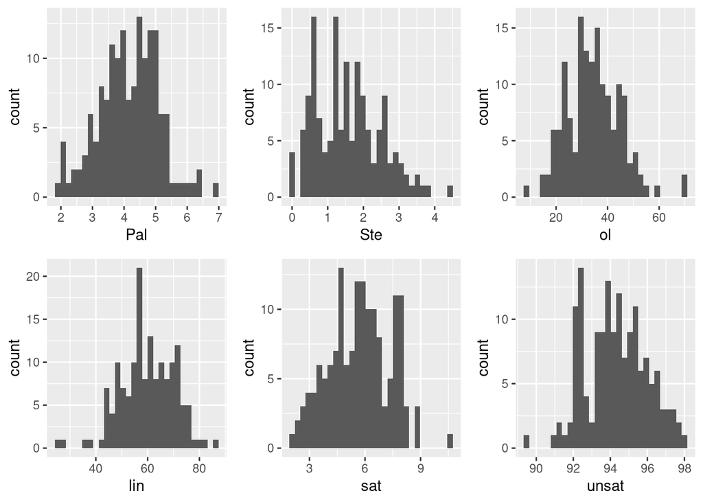

Distribution of oil traits.

```r
# Responses
r0 <- ggplot(data = dat, aes(x=Pal)) + geom_histogram()
r1 <- ggplot(data = dat, aes(x=Ste)) + geom_histogram()
r2 <- ggplot(data = dat, aes(x=ol)) + geom_histogram()
r3 <- ggplot(data = dat, aes(x=lin)) + geom_histogram()
r4 <- ggplot(data = dat, aes(x=sat)) + geom_histogram()
r5 <- ggplot(data = dat, aes(x=unsat)) + geom_histogram()

plot_grid(r0, r1, r2, r3, r4, r5, ncol = 3, nrow = 2)
```

It looks like a lot of the variation in the percent saturatted fatty acids is driven by variation of Pal.

And let’s take a look at all of the predictor distributions.

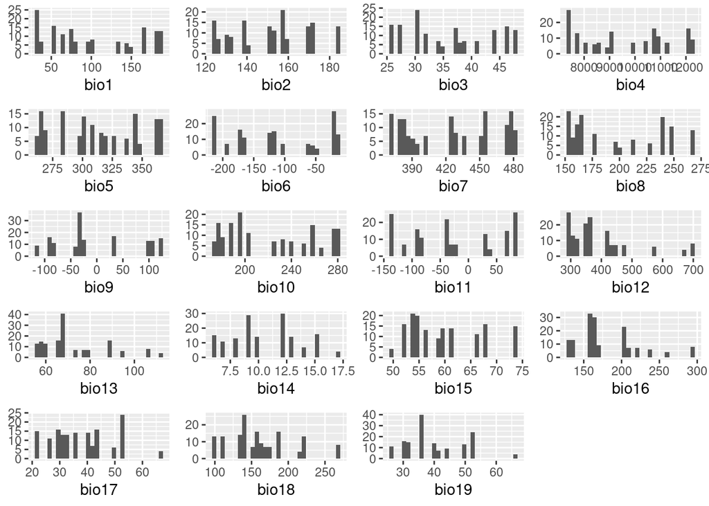

Distribution of 19 bioclim variables

```r
# Predictors
p0  <- ggplot(data = dat, aes(x=bio1 )) + geom_histogram() + theme(axis.title.y = element_blank())
p1  <- ggplot(data = dat, aes(x=bio2 )) + geom_histogram() + theme(axis.title.y = element_blank())
p2  <- ggplot(data = dat, aes(x=bio3 )) + geom_histogram() + theme(axis.title.y = element_blank())
p3  <- ggplot(data = dat, aes(x=bio4 )) + geom_histogram() + theme(axis.title.y = element_blank())
p4  <- ggplot(data = dat, aes(x=bio5 )) + geom_histogram() + theme(axis.title.y = element_blank())
p5  <- ggplot(data = dat, aes(x=bio6 )) + geom_histogram() + theme(axis.title.y = element_blank())
p6  <- ggplot(data = dat, aes(x=bio7 )) + geom_histogram() + theme(axis.title.y = element_blank())
p7  <- ggplot(data = dat, aes(x=bio8 )) + geom_histogram() + theme(axis.title.y = element_blank())
p8  <- ggplot(data = dat, aes(x=bio9 )) + geom_histogram() + theme(axis.title.y = element_blank())
p9  <- ggplot(data = dat, aes(x=bio10)) + geom_histogram() + theme(axis.title.y = element_blank())
p10 <- ggplot(data = dat, aes(x=bio11)) + geom_histogram() + theme(axis.title.y = element_blank())
p11 <- ggplot(data = dat, aes(x=bio12)) + geom_histogram() + theme(axis.title.y = element_blank())
p12 <- ggplot(data = dat, aes(x=bio13)) + geom_histogram() + theme(axis.title.y = element_blank())
p13 <- ggplot(data = dat, aes(x=bio14)) + geom_histogram() + theme(axis.title.y = element_blank())
p14 <- ggplot(data = dat, aes(x=bio15)) + geom_histogram() + theme(axis.title.y = element_blank())
p15 <- ggplot(data = dat, aes(x=bio16)) + geom_histogram() + theme(axis.title.y = element_blank())
p16 <- ggplot(data = dat, aes(x=bio17)) + geom_histogram() + theme(axis.title.y = element_blank())
p17 <- ggplot(data = dat, aes(x=bio18)) + geom_histogram() + theme(axis.title.y = element_blank())
p18 <- ggplot(data = dat, aes(x=bio19)) + geom_histogram() + theme(axis.title.y = element_blank())

plot_grid(p0, p1, p2, p3, p4, p5,
          p6, p7, p8, p9, p10, p11,
          p12, p13, p14, p15, p16,
          p17, p18,
          ncol = 4, nrow = 5)
```

Now that we have a sense for the data, fit a model

### Ancestry data

Figure out which ancestry data I have access to. If I can get the q-matrix from McAssey 2016, I’ll use it. Otherwise I may have to remake it.

I have to convert the GenAlEx format to some other format. Figure out if Ed can send you the K2 q-matrix, if not, convert the GenAlEx format to the input for ADMIXTURE. Then generate a K2 file.

I’m going to have to do this anyway if I want to do a Qst-Fst analysis.

## Bayesian models

```r
# This is running on thinkpad in a screen
# Still waiting for qmatrix - just make it. You'll need the data ready if you want to do qst-fst analyses
mod1 <- brm(sat ~ bio1 + bio2 + bio3 + bio4 +
              bio5 + bio6 + bio7 + bio8 + bio9 +
              bio10 + bio11 + bio12 + bio13 + bio14 +
              bio15 + bio16 + bio17 + bio18 + bio19 +
              lat + lon + # remove the effect of latitude & longitude
              (1|pop_code),
            data = dat,
            family = "gaussian",
            chains = 4L, seed = 2398, iter = 8000,
            cores = getOption("mc.cores", 4L),
            control = list(adapt_delta = 0.99, max_treedepth = 15)) %>%
  add_criterion("loo", reloo = TRUE)
save(mod1, file="mod1.brms")
```

### Bayesian model goodness of fit

I like the approach of assessing models by predicting data from a training set and then determining the goodness of fit from a validation set. I’ll do this here with the Bayesian fit.

```r
# Plot the posterior predictive distribtuions to evaluate goodnes of fit.
pp_interval <- pp_check(mod0, type = "intervals") # this one is great for viewing clustering of the data.
```

```
## Using all posterior samples for ppc type 'intervals' by default.
```

```r
pp_dens <- pp_check(mod0, type="dens_overlay") # good for viewing entire distribution
```

```
## Using 10 posterior samples for ppc type 'dens_overlay' by default.
```

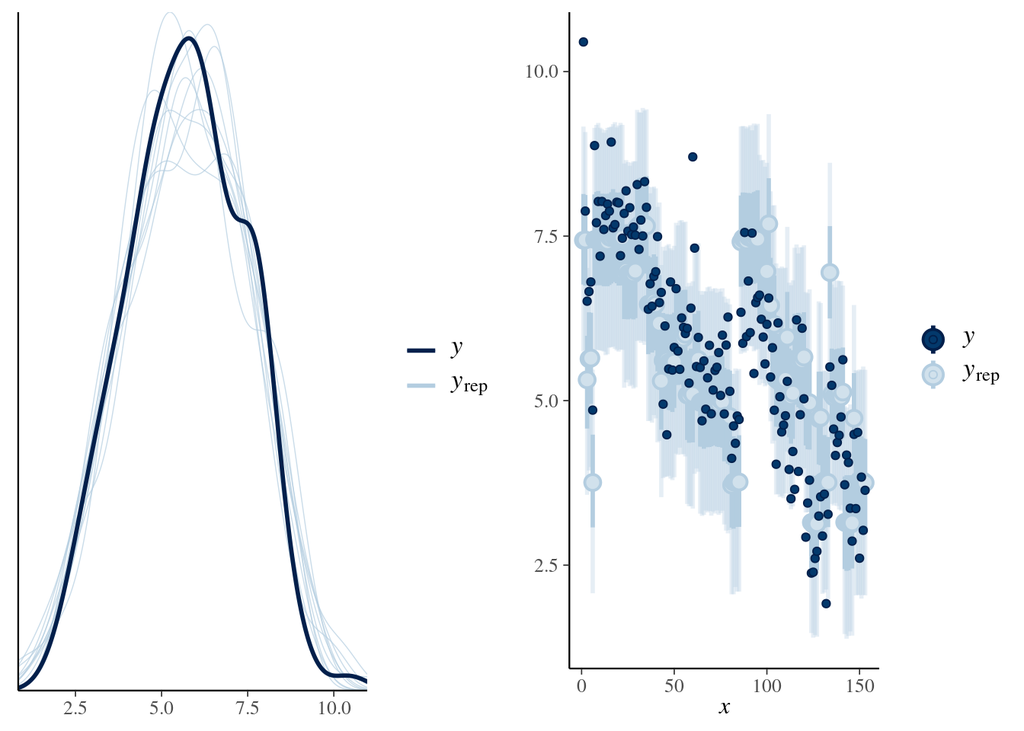

```r
plot_grid(pp_dens, pp_interval)
```

#### Plot all regression coefs

Forest plot of the regression coefficients

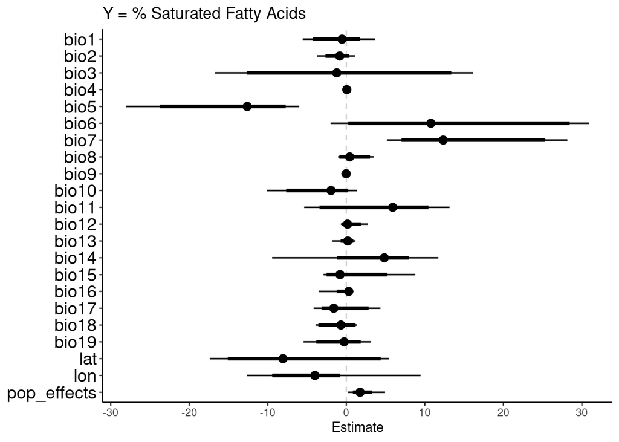

### Condional effects - main terms.

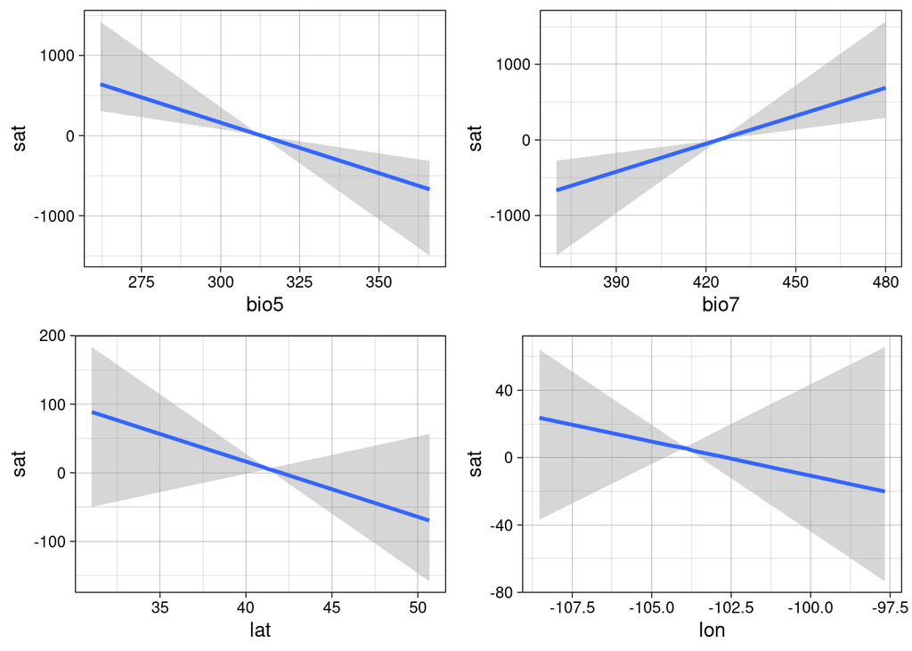

```r
# Calculate the conditional effects
ce <- conditional_effects(mod0)

# Plot interesting ones
bio5.ce <- plot(ce, plot = FALSE)[[5]] + theme_linedraw() + labs(color="", fill="")
bio7.ce <- plot(ce, plot = FALSE)[[7]] + theme_linedraw() + labs(color="", fill="")
lat.ce <- plot(ce, plot = FALSE)[[20]] + theme_linedraw() + labs(color="", fill="")
lon.ce <- plot(ce, plot = FALSE)[[21]] + theme_linedraw() + labs(color="", fill="")

plot_grid(bio5.ce, bio7.ce, lat.ce, lon.ce, ncol = 2)
```

### Interactions between terms

I think plotting the interaction between bio7 and bio14 would be interesting.